# How does a bike-share navigate speedy success?

Eric L Sammons

2023-07-19

## Hypothesis / Question

Based on bike share rider data, what steps could we take to convert more casual riders to a paid membership?

## Setup

### Set variables

```r
base_url <- "https://divvy-tripdata.s3.amazonaws.com/"  # Replace with the actual URL
destination_folder <- "data/"
months <- c("202205", "202206", "202207", "202208", "202209", "202210",
            "202211", "202212", "202301", "202302", "202303", "202304", "202305")
```

## Functions required to download and validate data files

```r
download_and_extract_csv <- function(url, destination_folder) {
  # Extract the filename from the URL
  filename <- basename(url)

  # Download the zip file
  if (!file.exists(paste0(destination_folder, filename))) {
    download.file(url, destfile = paste0(destination_folder, filename))

    # Extract the CSV file from the zip
    unzip(zipfile = paste0(destination_folder, filename),
          files = gsub("\\..*", ".csv", filename),
          exdir = destination_folder)
  }
}
```

```r
check_column_names <- function(file_paths) {
  # Read the column names from the first file
  column_names <- fread(file_paths[1])$names

  # Check column names in all files
  all_same <- all(sapply(file_paths, function(path) {
    identical(column_names, fread(path)$names)
  }))

  return(all_same)
}
```

## Download and Extract data files

```r
for (month in months) {
  url <- paste0(base_url, month, "-divvy-tripdata.zip")
  download_and_extract_csv(url, destination_folder)
}
```

## Validate the datafiles and create a single dataframe

Column names must be the same across all CSV files. If column names are not the same additional work will be required and is outside the scope of this effort.

```r
csv_files <- list.files(destination_folder, pattern = "\\.csv$", full.names = TRUE)

if (!check_column_names(csv_files)) {
  stop("Not all files have the same column names.")
}

df <- map_dfr(csv_files, read_csv)
```

## Housekeeping

### Remove columns not required

For our analysis we will not require the following colunns:

- start_lat
- start_lng
- end_lat
- end_lng

```r
df <- df %>%
  select(-c(start_lat, start_lng, end_lat, end_lng))

colnames(df)
```

```
## [1] "ride_id"            "rideable_type"      "started_at"
## [4] "ended_at"           "start_station_name" "start_station_id"
## [7] "end_station_name"   "end_station_id"     "member_casual"
```

## Rider type summary

```r
table(df$member_casual)
```

```
##
##  casual  member
## 2295791 3466758
```

## Data transformations

### Break down the started_at column

```r
df$date <- as.Date(df$started_at)
df$month <- format(as.Date(df$date), "%m")
df$day <- format(as.Date(df$date), "%d")
df$year <- format(as.Date(df$date), "%Y")
df$day_of_week <- format(as.Date(df$date), "%A")
```

### Create ride_length column

```r
df$ride_length <- difftime(df$ended_at, df$started_at)
df$ride_length <- as.numeric(df$ride_length)

str(df$ride_length)
```

```
##  num [1:5762549] 2001 2274 1310 522 301 ...
```

### Remove rows with ride_length < 0

```r
df <- df[!(df$ride_length < 0),]
```

## Analysis

### Ride length summary

```r
summary(df$ride_length)
```

```
##    Min. 1st Qu.  Median    Mean 3rd Qu.    Max.
##       0     337     599    1134    1078 2483235
```

### Ride length summary member vs casual

```r
comparison <- aggregate(df$ride_length, by = list(df$member_casual), FUN = function(x)
  c(mean = mean(x),
    median = median(x),
    max = max(x),
    min = min(x)))

comparison
```

```
##   Group.1       x.mean     x.median        x.max        x.min
## 1  casual    1713.7843     756.0000 2483235.0000       0.0000
## 2  member     750.1513     519.0000   93580.0000       0.0000
```

### Average ride time by day of week and member type

Here we look at the mean *ride_length* grouped by *day_of_week* and *member_casual*

```
## # A tibble: 14 × 3
## # Groups:   day_of_week [7]
##    day_of_week member_casual  mean
##    <fct>       <chr>         <dbl>
##  1 Sunday      casual        1998.
##  2 Sunday      member         834.
##  3 Monday      casual        1697.
##  4 Monday      member         719.
##  5 Tuesday     casual        1554.
##  6 Tuesday     member         722.
##  7 Wednesday   casual        1454.
##  8 Wednesday   member         714.
##  9 Thursday    casual        1524.
## 10 Thursday    member         725.
## 11 Friday      casual        1657.
## 12 Friday      member         737.
## 13 Saturday    casual        1905.
## 14 Saturday    member         833.
```

### Quick Look At Average Duration vs. Number of Rides

[figure not shown]

### Bike Share: Number of Rides By Weekday and Rider Type

Here we visualize the number of rides by day of week and whether the rider is a member of casual.

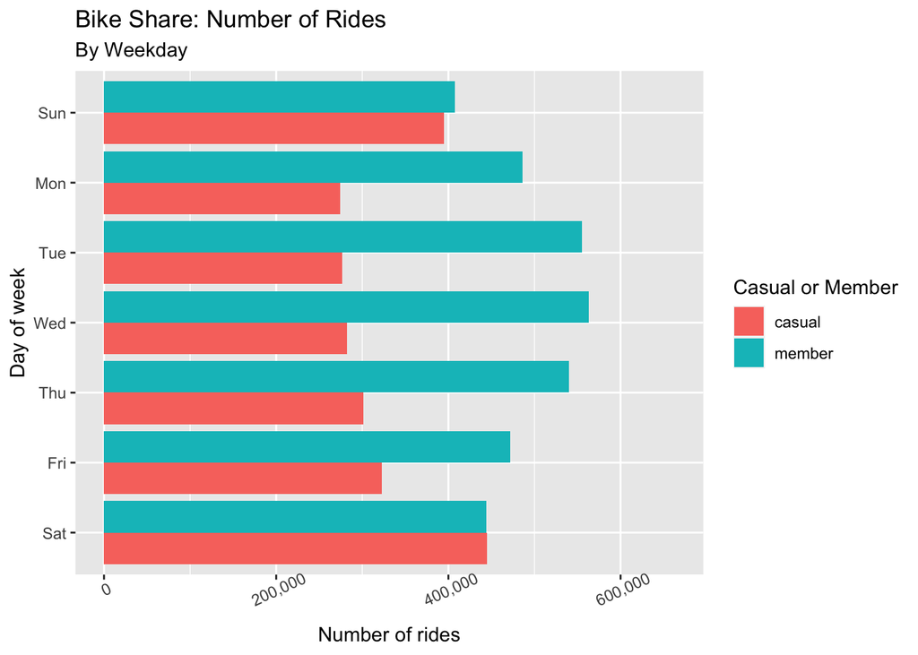

### Bike Share: Average Duration By Weekday

Here we visualize the average duration of rides by day of week and whether the rider is a member of casual.

[figure not shown]

## Conclusion

In conclusion we find the following that casual riders are riding longer, on average, vs their member counterparts. However, we see that there are far more member riders than casual riders on most days of the week. On weekends we do see that the number of casual rides vs member rides are nearly the same.

## Recommendation

Based on our findings here the following recommendaions may help convert casual riders to a paid membership.

- Introduce a weekend only membership that includes discounts for riding on weekdays.
- Introduce a discount program for members who ride longer.